# Final_Modeling_Data_Donaldson_Ian

Ian Donaldson

2023-10-23

# Introduction

## Project Goal

In this exploration, we aim to delve into Home Credit’s dataset, with a focus on understanding crucial features and identifying any necessary data cleaning processes. Our ultimate objective is to create a predictive model capable of determining whether a customer will successfully repay a loan or default.

## Business Problem

Home Credit operates in rapidly growing and developing markets where many consumers are “unbanked,” lacking traditional credit scores common in more developed economies. To maintain acceptable levels of loan losses while expanding its lending portfolio, Home Credit requires a predictive model that leverages alternative data sources, such as transactional information and telecommunications data, to assess the likelihood of customer loan default.

## Analytics Problem

Our analytics problem centers around building a machine-learning classification model that predicts loan defaults. Historical data from past customers in the training dataset, including transactional and telco information, will serve as input features. This model will then be used to predict the probability of default for previously unseen customers in the test dataset with effectiveness measured by AUC-ROC.

## Purpose of EDA Notebook

This EDA notebook serves as the cornerstone of our data-driven approach to addressing the Home Credit Default Risk problem. It marks the initial step in our data science journey, enabling us to thoroughly grasp the dataset, identify potential challenges, and make informed decisions regarding data preprocessing and feature engineering.

## Questions About Data

As part of our exploration, answers to the following questions will be sought: - Can the features of data be categorized into a set of general topics? - How many missing values are there in each column?  
- How many total missing values are there  
- Is the target variable (loan default) balanced or unbalanced, and what is the percentage distribution?  
- What accuracy can be achieved with a simple majority class classifier?  
- What are key issues with the unprocessed data?  
- Are there any strong predictors that should be included in our predictive model?  
- What is the extent of missing data, and what strategies should be employed to handle it?  
- Are there any outliers in the data, and how should they be handled?  
- Do the data values align with expectations, and are there any erroneous values requiring cleaning?  
- Are there any columns with near-zero or zero variance?  
- Will data transformation be necessary to prepare it for modeling?

## Setup

```r
#Length Output Silenced for Readability
#load packages
library('tidyverse')
library('skimr')
library('janitor')
library('caret')
library('tictoc')
library('car')
library('corrplot')
library('glmnet')
library('ROCR')
library('missForest')
library('ISLR')
library('pROC')
library('ROSE')
library('rminer')

#load data
clean_train <- read_csv('clean_train.csv') %>%
  mutate_if(is.character, as.factor)

#set TARGET Variable as Factor with No and Yes for Levels (caret errors otherwise)
clean_train$TARGET <- factor(clean_train$TARGET,
                             levels = c(0, 1), labels = c('No', 'Yes'))
```

Load packages and the preprocessed data.

## Logistic Regression

```r
#Validate Distribution of Target Variable
prop.table(table(clean_train$TARGET))
```

```
##
##         No        Yes
## 0.91927013 0.08072987
```

```r
#time
tic()

#Logistic Model
logicModel <- glm(TARGET ~ ., data = clean_train, family = binomial(link = 'logit'))

#time
toc()
```

```
## 8.163 sec elapsed
```

```r
#Summary of Model
summary(logicModel)
```

```
##
## Call:
## glm(formula = TARGET ~ ., family = binomial(link = "logit"),
##     data = clean_train)
##
## Coefficients:
##                                                    Estimate Std. Error z value
## (Intercept)                                      -9.538e+00  6.144e+01  -0.155
## NAME_CONTRACT_TYPERevolving loans                -2.854e-01  3.249e-02  -8.784
## CODE_GENDERM                                      3.687e-01  1.565e-02  23.565
## FLAG_OWN_CARY                                    -2.767e-01  1.614e-02 -17.145
## FLAG_OWN_REALTYY                                  8.359e-02  1.515e-02   5.517
## NAME_INCOME_TYPECommercial associate              7.631e+00  6.144e+01   0.124
## NAME_INCOME_TYPEMaternity leave                   1.055e+01  6.145e+01   0.172
## NAME_INCOME_TYPEPensioner                         7.407e+00  6.144e+01   0.121
## NAME_INCOME_TYPEState servant                     7.449e+00  6.144e+01   0.121
## NAME_INCOME_TYPEStudent                          -1.667e+00  7.471e+01  -0.022
## NAME_INCOME_TYPEUnemployed                        9.750e+00  6.144e+01   0.159
## NAME_INCOME_TYPEWorking                           7.732e+00  6.144e+01   0.126
## NAME_EDUCATION_TYPEHigher education               1.269e+00  5.904e-01   2.149
## NAME_EDUCATION_TYPEIncomplete higher              1.402e+00  5.914e-01   2.371
## NAME_EDUCATION_TYPELower secondary                1.817e+00  5.927e-01   3.065
## NAME_EDUCATION_TYPESecondary / secondary special  1.663e+00  5.903e-01   2.817
## DAYS_BIRTH                                        3.141e-06  2.366e-06   1.328
## DAYS_EMPLOYED                                    -8.191e-05  4.227e-06 -19.380
## DAYS_REGISTRATION                                -9.869e-06  2.195e-06  -4.497
## DAYS_ID_PUBLISH                                  -4.647e-05  4.837e-06  -9.606
## FLAG_WORK_PHONE                                   1.138e-01  1.790e-02   6.362
## FLAG_PHONE                                       -1.110e-01  1.690e-02  -6.563
## FLAG_EMAIL                                       -7.607e-02  3.046e-02  -2.497
## CNT_FAM_MEMBERS                                  -1.078e-02  7.747e-03  -1.392
## REGION_RATING_CLIENT_W_CITY                       1.449e-01  1.467e-02   9.880
## LIVE_REGION_NOT_WORK_REGION                      -6.854e-02  3.495e-02  -1.961
## REG_CITY_NOT_LIVE_CITY                            1.631e-01  2.247e-02   7.259
## EXT_SOURCE_1                                     -1.194e+00  5.378e-02 -22.210
## EXT_SOURCE_2                                     -2.150e+00  3.478e-02 -61.816
## EXT_SOURCE_3                                     -2.661e+00  3.804e-02 -69.959
## FLAG_DOCUMENT_3                                   1.726e-01  1.970e-02   8.766
## log_AMT_INCOME_TOTAL                             -6.516e-02  1.785e-02  -3.650
## log_AMT_CREDIT                                    1.009e-01  1.143e-02   8.821
```

[output cut: 29 more lines]

```
## EXT_SOURCE_2                                      < 2e-16 ***
## EXT_SOURCE_3                                      < 2e-16 ***
## FLAG_DOCUMENT_3                                   < 2e-16 ***
## log_AMT_INCOME_TOTAL                             0.000262 ***
## log_AMT_CREDIT                                    < 2e-16 ***
## ---
## Signif. codes:  0 '***' 0.001 '**' 0.01 '*' 0.05 '.' 0.1 ' ' 1
##
## (Dispersion parameter for binomial family taken to be 1)
##
##     Null deviance: 172541  on 307506  degrees of freedom
## Residual deviance: 154894  on 307474  degrees of freedom
## AIC: 154960
##
## Number of Fisher Scoring iterations: 10
```

```r
#Variable Importance
varImp(logicModel, scale = TRUE)
```

```
##                                                      Overall
## NAME_CONTRACT_TYPERevolving loans                 8.78420020
## CODE_GENDERM                                     23.56500891
## FLAG_OWN_CARY                                    17.14491872
## FLAG_OWN_REALTYY                                  5.51651650
## NAME_INCOME_TYPECommercial associate              0.12419922
## NAME_INCOME_TYPEMaternity leave                   0.17172098
## NAME_INCOME_TYPEPensioner                         0.12055603
## NAME_INCOME_TYPEState servant                     0.12124446
## NAME_INCOME_TYPEStudent                           0.02231658
## NAME_INCOME_TYPEUnemployed                        0.15868905
## NAME_INCOME_TYPEWorking                           0.12583986
## NAME_EDUCATION_TYPEHigher education               2.14945052
## NAME_EDUCATION_TYPEIncomplete higher              2.37109971
## NAME_EDUCATION_TYPELower secondary                3.06478047
## NAME_EDUCATION_TYPESecondary / secondary special  2.81736444
## DAYS_BIRTH                                        1.32753812
## DAYS_EMPLOYED                                    19.37979875
## DAYS_REGISTRATION                                 4.49690301
## DAYS_ID_PUBLISH                                   9.60630114
## FLAG_WORK_PHONE                                   6.36150190
## FLAG_PHONE                                        6.56335505
## FLAG_EMAIL                                        2.49734309
## CNT_FAM_MEMBERS                                   1.39179444
## REGION_RATING_CLIENT_W_CITY                       9.87958999
## LIVE_REGION_NOT_WORK_REGION                       1.96100899
## REG_CITY_NOT_LIVE_CITY                            7.25934301
## EXT_SOURCE_1                                     22.20977034
## EXT_SOURCE_2                                     61.81587993
## EXT_SOURCE_3                                     69.95858724
## FLAG_DOCUMENT_3                                   8.76573595
## log_AMT_INCOME_TOTAL                              3.64975863
## log_AMT_CREDIT                                    8.82072719
```

```r
#Select Important variables over ~8% importance
varImp8 <- varImp(logicModel, scale = TRUE) %>%
  as.data.frame() %>%
  rownames_to_column() %>%
  filter(Overall > 8)

#Display Important Variables
varImp8
```

```
##                              rowname   Overall
## 1  NAME_CONTRACT_TYPERevolving loans  8.784200
## 2                       CODE_GENDERM 23.565009
## 3                      FLAG_OWN_CARY 17.144919
## 4                      DAYS_EMPLOYED 19.379799
## 5                    DAYS_ID_PUBLISH  9.606301
## 6        REGION_RATING_CLIENT_W_CITY  9.879590
## 7                       EXT_SOURCE_1 22.209770
## 8                       EXT_SOURCE_2 61.815880
## 9                       EXT_SOURCE_3 69.958587
## 10                   FLAG_DOCUMENT_3  8.765736
## 11                    log_AMT_CREDIT  8.820727
```

Predictor selection for the logihis was accomplished using varImp() to determine the most important variables in the logistic model. Variables with an importance of greater than 8% were selected for further analysis. After initial preprocessing of data this identified the following predictors: NAME_CONTRACT_TYPE, CODE_GENDER, FLAG_OWN_CAR+DAYS_EMPLOYED, DAYS_ID_PUBLISH, REGION_RATING_CLIENT_W_CITY, EXT_SOURCE_1, EXT_SOURCE_, EXT_SOURCE_3 , FLAG_DOCUMENT_3, and log_AMT_CREDIT.

```r
#set train control for downsampled data
traincntrlDown <- trainControl(method = 'repeatedcv',
                             number = 5,
                             repeats = 2,
                             classProbs = TRUE,
                             sampling = "down",
                             summaryFunction = twoClassSummary)

#set train control for upsampled data
traincntrlUp <- trainControl(method = 'repeatedcv',
                             number = 5,
                             repeats = 2,
                             classProbs = TRUE,
                             sampling = "up",
                             summaryFunction = twoClassSummary)
```

Set train control for downsampled and upsampled data using repeatee cross validation with 5 folds and 2 repeats. Class probabilities are set to true. Downsampling and upsampling are used to test addressing the unbalanced dataset.

```r
#Split train and test 70/30
set.seed(123)

#Create index for 70/30 split
inTrain <- createDataPartition(clean_train$TARGET, p = 0.7, list = FALSE)

#Create train and test datasets
appTrain <- clean_train[inTrain, ]
appTest <- clean_train[-inTrain, ]

#Check distribution of target variable in train and test
prop.table(table(appTrain$TARGET))
```

```
##
##         No        Yes
## 0.91926822 0.08073178
```

```r
prop.table(table(appTest$TARGET))
```

```
##
##         No        Yes
## 0.91927459 0.08072541
```

Split data into 70% train and 30% test sets. The target variable is still unbalanced in the train and test sets at 8.07%.

```r
#time
tic()

#Create logistic model with only important variables
logitModel <- glm(TARGET ~ NAME_CONTRACT_TYPE+CODE_GENDER+
                    FLAG_OWN_CAR+DAYS_EMPLOYED+
                    DAYS_ID_PUBLISH+REGION_RATING_CLIENT_W_CITY+
                    EXT_SOURCE_1+EXT_SOURCE_2+
                    EXT_SOURCE_3+FLAG_DOCUMENT_3+
                    log_AMT_CREDIT, data = clean_train,
                  family = binomial(link = 'logit'))

#time
toc()
```

```
## 1.319 sec elapsed
```

```r
#time
tic()

logitModelDown <- train(TARGET ~ NAME_CONTRACT_TYPE+CODE_GENDER+
                    FLAG_OWN_CAR+DAYS_EMPLOYED+
                    DAYS_ID_PUBLISH+REGION_RATING_CLIENT_W_CITY+
                    EXT_SOURCE_1+EXT_SOURCE_2+
                    EXT_SOURCE_3+FLAG_DOCUMENT_3+
                    log_AMT_CREDIT, data = clean_train,
                    method = "glm",
                    trControl = traincntrlDown)

#time
toc()
```

```
## 11.796 sec elapsed
```

```r
#time
tic()

logitModelUp <- train(TARGET ~ NAME_CONTRACT_TYPE+CODE_GENDER+
                    FLAG_OWN_CAR+DAYS_EMPLOYED+
                    DAYS_ID_PUBLISH+REGION_RATING_CLIENT_W_CITY+
                    EXT_SOURCE_1+EXT_SOURCE_2+
                    EXT_SOURCE_3+FLAG_DOCUMENT_3+
                    log_AMT_CREDIT, data = clean_train,
                    method = "glm",
                    trControl = traincntrlUp)
toc()
```

```
## 30.456 sec elapsed
```

```r
#Compare AIC of models
summary(logitModel)
```

```
##
## Call:
## glm(formula = TARGET ~ NAME_CONTRACT_TYPE + CODE_GENDER + FLAG_OWN_CAR +
##     DAYS_EMPLOYED + DAYS_ID_PUBLISH + REGION_RATING_CLIENT_W_CITY +
##     EXT_SOURCE_1 + EXT_SOURCE_2 + EXT_SOURCE_3 + FLAG_DOCUMENT_3 +
##     log_AMT_CREDIT, family = binomial(link = "logit"), data = clean_train)
##
## Coefficients:
##                                     Estimate Std. Error z value Pr(>|z|)
## (Intercept)                       -5.485e-01  1.424e-01  -3.851 0.000118 ***
## NAME_CONTRACT_TYPERevolving loans -2.388e-01  3.161e-02  -7.555 4.18e-14 ***
## CODE_GENDERM                       4.068e-01  1.506e-02  27.014  < 2e-16 ***
## FLAG_OWN_CARY                     -2.917e-01  1.580e-02 -18.462  < 2e-16 ***
## DAYS_EMPLOYED                     -8.035e-05  4.054e-06 -19.820  < 2e-16 ***
## DAYS_ID_PUBLISH                   -5.872e-05  4.604e-06 -12.752  < 2e-16 ***
## REGION_RATING_CLIENT_W_CITY        1.730e-01  1.413e-02  12.246  < 2e-16 ***
## EXT_SOURCE_1                      -1.324e+00  4.947e-02 -26.757  < 2e-16 ***
## EXT_SOURCE_2                      -2.240e+00  3.429e-02 -65.333  < 2e-16 ***
## EXT_SOURCE_3                      -2.634e+00  3.735e-02 -70.519  < 2e-16 ***
## FLAG_DOCUMENT_3                    2.672e-01  1.854e-02  14.410  < 2e-16 ***
## log_AMT_CREDIT                     6.082e-02  1.038e-02   5.860 4.62e-09 ***
## ---
## Signif. codes:  0 '***' 0.001 '**' 0.01 '*' 0.05 '.' 0.1 ' ' 1
##
## (Dispersion parameter for binomial family taken to be 1)
##
##     Null deviance: 172541  on 307506  degrees of freedom
## Residual deviance: 155955  on 307495  degrees of freedom
## AIC: 155979
##
## Number of Fisher Scoring iterations: 6
```

```r
summary(logitModelDown)
```

```
##
## Call:
## NULL
##
## Coefficients:
##                                       Estimate Std. Error z value Pr(>|z|)
## (Intercept)                          2.330e+00  2.095e-01  11.121  < 2e-16 ***
## `NAME_CONTRACT_TYPERevolving loans` -2.477e-01  4.279e-02  -5.788 7.13e-09 ***
## CODE_GENDERM                         4.035e-01  2.182e-02  18.491  < 2e-16 ***
## FLAG_OWN_CARY                       -3.080e-01  2.244e-02 -13.723  < 2e-16 ***
## DAYS_EMPLOYED                       -7.660e-05  5.261e-06 -14.559  < 2e-16 ***
## DAYS_ID_PUBLISH                     -6.975e-05  6.543e-06 -10.661  < 2e-16 ***
## REGION_RATING_CLIENT_W_CITY          1.792e-01  2.044e-02   8.763  < 2e-16 ***
## EXT_SOURCE_1                        -1.585e+00  7.479e-02 -21.193  < 2e-16 ***
## EXT_SOURCE_2                        -2.230e+00  5.132e-02 -43.464  < 2e-16 ***
## EXT_SOURCE_3                        -2.719e+00  5.556e-02 -48.940  < 2e-16 ***
## FLAG_DOCUMENT_3                      2.355e-01  2.570e-02   9.163  < 2e-16 ***
## log_AMT_CREDIT                       4.225e-02  1.523e-02   2.774  0.00554 **
## ---
## Signif. codes:  0 '***' 0.001 '**' 0.01 '*' 0.05 '.' 0.1 ' ' 1
##
## (Dispersion parameter for binomial family taken to be 1)
##
##     Null deviance: 68830  on 49649  degrees of freedom
## Residual deviance: 60211  on 49638  degrees of freedom
## AIC: 60235
##
## Number of Fisher Scoring iterations: 4
```

```r
summary(logitModelUp)
```

```
##
## Call:
## NULL
##
## Coefficients:
##                                       Estimate Std. Error z value Pr(>|z|)
## (Intercept)                          1.919e+00  6.202e-02   30.94   <2e-16 ***
## `NAME_CONTRACT_TYPERevolving loans` -2.318e-01  1.260e-02  -18.40   <2e-16 ***
## CODE_GENDERM                         4.248e-01  6.490e-03   65.44   <2e-16 ***
## FLAG_OWN_CARY                       -3.071e-01  6.666e-03  -46.08   <2e-16 ***
## DAYS_EMPLOYED                       -7.931e-05  1.559e-06  -50.85   <2e-16 ***
## DAYS_ID_PUBLISH                     -6.186e-05  1.941e-06  -31.87   <2e-16 ***
## REGION_RATING_CLIENT_W_CITY          1.796e-01  6.084e-03   29.52   <2e-16 ***
## EXT_SOURCE_1                        -1.552e+00  2.210e-02  -70.23   <2e-16 ***
## EXT_SOURCE_2                        -2.277e+00  1.525e-02 -149.36   <2e-16 ***
## EXT_SOURCE_3                        -2.674e+00  1.646e-02 -162.43   <2e-16 ***
## FLAG_DOCUMENT_3                      2.539e-01  7.616e-03   33.34   <2e-16 ***
## log_AMT_CREDIT                       6.931e-02  4.504e-03   15.39   <2e-16 ***
## ---
## Signif. codes:  0 '***' 0.001 '**' 0.01 '*' 0.05 '.' 0.1 ' ' 1
##
## (Dispersion parameter for binomial family taken to be 1)
##
##     Null deviance: 783761  on 565363  degrees of freedom
## Residual deviance: 685555  on 565352  degrees of freedom
## AIC: 685579
##
## Number of Fisher Scoring iterations: 4
```

```r
#Balanced data set with both over and under sampling
data.balanced.ou <- ovun.sample(TARGET~., data=appTrain,
                                N=nrow(appTrain), p=0.5,
                                seed=1, method="both")$data

#Check distribution of target variable in balanced data
table(data.balanced.ou$TARGET)
```

```
##
##     No    Yes
## 107498 107758
```

```r
#Balanced data set with over-sampling
data.balanced.over <- ovun.sample(TARGET~., data=appTrain,
                                  p=0.5, seed=1,
                                  method="over")$data

#Check distribution of target variable in oversampled
table(data.balanced.over$TARGET)
```

```
##
##     No    Yes
## 197878 198122
```

```r
#Balanced data set with under-sampling
data.balanced.under <- ovun.sample(TARGET~., data=appTrain,
                                   p=0.5, seed=1,
                                   method="under")$data

#Check distribution of target variable in undersampled data
table(data.balanced.under$TARGET)
```

```
##
##    No   Yes
## 17314 17378
```

```r
#time
tic()

#Logistic Model with balanced data
logicModelou<- glm(TARGET ~ NAME_CONTRACT_TYPE+CODE_GENDER+
                    FLAG_OWN_CAR+DAYS_EMPLOYED+
                    DAYS_ID_PUBLISH+REGION_RATING_CLIENT_W_CITY+
                    EXT_SOURCE_1+EXT_SOURCE_2+
                    EXT_SOURCE_3+FLAG_DOCUMENT_3+
                    log_AMT_CREDIT, data = data.balanced.ou,
                  family = binomial(link = 'logit'))

#time
toc()
```

```
## 0.617 sec elapsed
```

```r
#Distribution of target variable in balanced data
table(data.balanced.ou$TARGET)
```

```
##
##     No    Yes
## 107498 107758
```

```r
#Summary of Logistic Model over/under
summary(logicModelou)
```

```
##
## Call:
## glm(formula = TARGET ~ NAME_CONTRACT_TYPE + CODE_GENDER + FLAG_OWN_CAR +
##     DAYS_EMPLOYED + DAYS_ID_PUBLISH + REGION_RATING_CLIENT_W_CITY +
##     EXT_SOURCE_1 + EXT_SOURCE_2 + EXT_SOURCE_3 + FLAG_DOCUMENT_3 +
##     log_AMT_CREDIT, family = binomial(link = "logit"), data = data.balanced.ou)
##
## Coefficients:
##                                     Estimate Std. Error  z value Pr(>|z|)
## (Intercept)                        1.980e+00  1.003e-01   19.737   <2e-16 ***
## NAME_CONTRACT_TYPERevolving loans -2.142e-01  2.043e-02  -10.483   <2e-16 ***
## CODE_GENDERM                       4.467e-01  1.054e-02   42.379   <2e-16 ***
## FLAG_OWN_CARY                     -3.077e-01  1.081e-02  -28.455   <2e-16 ***
## DAYS_EMPLOYED                     -7.319e-05  2.517e-06  -29.074   <2e-16 ***
## DAYS_ID_PUBLISH                   -6.921e-05  3.140e-06  -22.040   <2e-16 ***
## REGION_RATING_CLIENT_W_CITY        1.900e-01  9.905e-03   19.186   <2e-16 ***
## EXT_SOURCE_1                      -1.552e+00  3.575e-02  -43.404   <2e-16 ***
## EXT_SOURCE_2                      -2.230e+00  2.470e-02  -90.266   <2e-16 ***
## EXT_SOURCE_3                      -2.717e+00  2.664e-02 -101.982   <2e-16 ***
## FLAG_DOCUMENT_3                    2.521e-01  1.238e-02   20.358   <2e-16 ***
## log_AMT_CREDIT                     6.294e-02  7.291e-03    8.633   <2e-16 ***
## ---
## Signif. codes:  0 '***' 0.001 '**' 0.01 '*' 0.05 '.' 0.1 ' ' 1
##
## (Dispersion parameter for binomial family taken to be 1)
##
##     Null deviance: 298408  on 215255  degrees of freedom
## Residual deviance: 260959  on 215244  degrees of freedom
## AIC: 260983
##
## Number of Fisher Scoring iterations: 4
```

```r
#time
tic()

#Logistic Model with balanced data using upsampled data
logicModelover <- glm(TARGET ~ NAME_CONTRACT_TYPE+CODE_GENDER+
                    FLAG_OWN_CAR+DAYS_EMPLOYED+
                    DAYS_ID_PUBLISH+REGION_RATING_CLIENT_W_CITY+
                    EXT_SOURCE_1+EXT_SOURCE_2+
                    EXT_SOURCE_3+FLAG_DOCUMENT_3+
                    log_AMT_CREDIT, data = data.balanced.over,
                  family = binomial(link = 'logit'))

#time
toc()
```

```
## 1.288 sec elapsed
```

```r
#Distribution of target variable in balanced data
table(data.balanced.over$TARGET)
```

```
##
##     No    Yes
## 197878 198122
```

```r
#Summary of Logistic Model over
summary(logicModelover)
```

```
##
## Call:
## glm(formula = TARGET ~ NAME_CONTRACT_TYPE + CODE_GENDER + FLAG_OWN_CAR +
##     DAYS_EMPLOYED + DAYS_ID_PUBLISH + REGION_RATING_CLIENT_W_CITY +
##     EXT_SOURCE_1 + EXT_SOURCE_2 + EXT_SOURCE_3 + FLAG_DOCUMENT_3 +
##     log_AMT_CREDIT, family = binomial(link = "logit"), data = data.balanced.over)
##
## Coefficients:
##                                     Estimate Std. Error z value Pr(>|z|)
## (Intercept)                        1.966e+00  7.401e-02   26.57   <2e-16 ***
## NAME_CONTRACT_TYPERevolving loans -2.142e-01  1.504e-02  -14.24   <2e-16 ***
## CODE_GENDERM                       4.403e-01  7.757e-03   56.76   <2e-16 ***
## FLAG_OWN_CARY                     -2.944e-01  7.965e-03  -36.96   <2e-16 ***
## DAYS_EMPLOYED                     -7.517e-05  1.853e-06  -40.57   <2e-16 ***
## DAYS_ID_PUBLISH                   -6.926e-05  2.313e-06  -29.94   <2e-16 ***
## REGION_RATING_CLIENT_W_CITY        1.813e-01  7.282e-03   24.89   <2e-16 ***
## EXT_SOURCE_1                      -1.542e+00  2.639e-02  -58.42   <2e-16 ***
## EXT_SOURCE_2                      -2.271e+00  1.827e-02 -124.27   <2e-16 ***
## EXT_SOURCE_3                      -2.667e+00  1.963e-02 -135.88   <2e-16 ***
## FLAG_DOCUMENT_3                    2.580e-01  9.127e-03   28.26   <2e-16 ***
## log_AMT_CREDIT                     6.464e-02  5.378e-03   12.02   <2e-16 ***
## ---
## Signif. codes:  0 '***' 0.001 '**' 0.01 '*' 0.05 '.' 0.1 ' ' 1
##
## (Dispersion parameter for binomial family taken to be 1)
##
##     Null deviance: 548972  on 395999  degrees of freedom
## Residual deviance: 480214  on 395988  degrees of freedom
## AIC: 480238
##
## Number of Fisher Scoring iterations: 4
```

```r
#time
tic()

#Logistic Model with balanced data using downsampled data
logicModelunder <- glm(TARGET ~ NAME_CONTRACT_TYPE+CODE_GENDER+
                    FLAG_OWN_CAR+DAYS_EMPLOYED+
                    DAYS_ID_PUBLISH+REGION_RATING_CLIENT_W_CITY+
                    EXT_SOURCE_1+EXT_SOURCE_2+
                    EXT_SOURCE_3+FLAG_DOCUMENT_3+
                    log_AMT_CREDIT, data = data.balanced.under,
                  family = binomial(link = 'logit'))
#time
toc()
```

```
## 0.093 sec elapsed
```

```r
#Distribution of target variable in balanced data
table(data.balanced.under$TARGET)
```

```
##
##    No   Yes
## 17314 17378
```

```r
#Summary of Logistic Model under
summary(logicModelunder)
```

```
##
## Call:
## glm(formula = TARGET ~ NAME_CONTRACT_TYPE + CODE_GENDER + FLAG_OWN_CAR +
##     DAYS_EMPLOYED + DAYS_ID_PUBLISH + REGION_RATING_CLIENT_W_CITY +
##     EXT_SOURCE_1 + EXT_SOURCE_2 + EXT_SOURCE_3 + FLAG_DOCUMENT_3 +
##     log_AMT_CREDIT, family = binomial(link = "logit"), data = data.balanced.under)
##
## Coefficients:
##                                     Estimate Std. Error z value Pr(>|z|)
## (Intercept)                        2.010e+00  2.513e-01   7.998 1.26e-15 ***
## NAME_CONTRACT_TYPERevolving loans -2.249e-01  5.072e-02  -4.435 9.22e-06 ***
## CODE_GENDERM                       4.484e-01  2.619e-02  17.123  < 2e-16 ***
## FLAG_OWN_CARY                     -2.692e-01  2.690e-02 -10.008  < 2e-16 ***
## DAYS_EMPLOYED                     -7.627e-05  6.237e-06 -12.229  < 2e-16 ***
## DAYS_ID_PUBLISH                   -5.617e-05  7.813e-06  -7.189 6.52e-13 ***
## REGION_RATING_CLIENT_W_CITY        1.546e-01  2.455e-02   6.298 3.02e-10 ***
## EXT_SOURCE_1                      -1.458e+00  8.908e-02 -16.369  < 2e-16 ***
## EXT_SOURCE_2                      -2.253e+00  6.147e-02 -36.642  < 2e-16 ***
## EXT_SOURCE_3                      -2.704e+00  6.633e-02 -40.758  < 2e-16 ***
## FLAG_DOCUMENT_3                    2.902e-01  3.081e-02   9.418  < 2e-16 ***
## log_AMT_CREDIT                     5.766e-02  1.826e-02   3.157  0.00159 **
## ---
## Signif. codes:  0 '***' 0.001 '**' 0.01 '*' 0.05 '.' 0.1 ' ' 1
##
## (Dispersion parameter for binomial family taken to be 1)
##
##     Null deviance: 48093  on 34691  degrees of freedom
## Residual deviance: 42138  on 34680  degrees of freedom
## AIC: 42162
##
## Number of Fisher Scoring iterations: 4
```

```r
#time
tic()

#Test polynomial model on EXT_SOURCE_*
logicModelunderpoly1 <- glm(TARGET ~ NAME_CONTRACT_TYPE+CODE_GENDER+
                    FLAG_OWN_CAR+DAYS_EMPLOYED+
                    DAYS_ID_PUBLISH+REGION_RATING_CLIENT_W_CITY+
                    poly(EXT_SOURCE_1,2)+poly(EXT_SOURCE_2,2)+
                    poly(EXT_SOURCE_3,2)+FLAG_DOCUMENT_3+
                    log_AMT_CREDIT, data = appTrain,
                    family = binomial(link = 'logit'))

#time
toc()
```

```
## 1.318 sec elapsed
```

```r
summary(logicModelunderpoly1)
```

```
##
## Call:
## glm(formula = TARGET ~ NAME_CONTRACT_TYPE + CODE_GENDER + FLAG_OWN_CAR +
##     DAYS_EMPLOYED + DAYS_ID_PUBLISH + REGION_RATING_CLIENT_W_CITY +
##     poly(EXT_SOURCE_1, 2) + poly(EXT_SOURCE_2, 2) + poly(EXT_SOURCE_3,
##     2) + FLAG_DOCUMENT_3 + log_AMT_CREDIT, family = binomial(link = "logit"),
##     data = appTrain)
##
## Coefficients:
##                                     Estimate Std. Error z value Pr(>|z|)
## (Intercept)                       -3.711e+00  1.701e-01 -21.814  < 2e-16 ***
## NAME_CONTRACT_TYPERevolving loans -2.137e-01  3.772e-02  -5.666 1.46e-08 ***
## CODE_GENDERM                       4.227e-01  1.798e-02  23.506  < 2e-16 ***
## FLAG_OWN_CARY                     -2.841e-01  1.888e-02 -15.044  < 2e-16 ***
## DAYS_EMPLOYED                     -7.978e-05  4.841e-06 -16.480  < 2e-16 ***
## DAYS_ID_PUBLISH                   -6.613e-05  5.505e-06 -12.013  < 2e-16 ***
## REGION_RATING_CLIENT_W_CITY        1.728e-01  1.697e-02  10.181  < 2e-16 ***
## poly(EXT_SOURCE_1, 2)1            -9.917e+01  4.589e+00 -21.609  < 2e-16 ***
## poly(EXT_SOURCE_1, 2)2            -2.587e+01  4.279e+00  -6.045 1.49e-09 ***
## poly(EXT_SOURCE_2, 2)1            -1.973e+02  3.981e+00 -49.563  < 2e-16 ***
## poly(EXT_SOURCE_2, 2)2             6.581e-01  3.572e+00   0.184 0.853813
## poly(EXT_SOURCE_3, 2)1            -2.069e+02  4.061e+00 -50.933  < 2e-16 ***
## poly(EXT_SOURCE_3, 2)2             1.301e+01  3.788e+00   3.435 0.000592 ***
## FLAG_DOCUMENT_3                    2.746e-01  2.222e-02  12.358  < 2e-16 ***
## log_AMT_CREDIT                     5.977e-02  1.242e-02   4.812 1.49e-06 ***
## ---
## Signif. codes:  0 '***' 0.001 '**' 0.01 '*' 0.05 '.' 0.1 ' ' 1
##
## (Dispersion parameter for binomial family taken to be 1)
##
##     Null deviance: 120781  on 215255  degrees of freedom
## Residual deviance: 109071  on 215241  degrees of freedom
## AIC: 109101
##
## Number of Fisher Scoring iterations: 6
```

```r
#time
tic()

#Test polynomial model on EXT_SOURCE_*
logicModelunderpoly2 <- glm(TARGET ~ NAME_CONTRACT_TYPE+CODE_GENDER+
                    FLAG_OWN_CAR+DAYS_EMPLOYED+
                    DAYS_ID_PUBLISH+REGION_RATING_CLIENT_W_CITY+
                    poly(EXT_SOURCE_1,2)+poly(EXT_SOURCE_2,1)+
                    poly(EXT_SOURCE_3,2)+FLAG_DOCUMENT_3+
                    log_AMT_CREDIT, data = appTrain,
                    family = binomial(link = 'logit'))

#time
toc()
```

```
## 1.104 sec elapsed
```

```r
summary(logicModelunderpoly2)
```

```
##
## Call:
## glm(formula = TARGET ~ NAME_CONTRACT_TYPE + CODE_GENDER + FLAG_OWN_CAR +
##     DAYS_EMPLOYED + DAYS_ID_PUBLISH + REGION_RATING_CLIENT_W_CITY +
##     poly(EXT_SOURCE_1, 2) + poly(EXT_SOURCE_2, 1) + poly(EXT_SOURCE_3,
##     2) + FLAG_DOCUMENT_3 + log_AMT_CREDIT, family = binomial(link = "logit"),
##     data = appTrain)
##
## Coefficients:
##                                     Estimate Std. Error z value Pr(>|z|)
## (Intercept)                       -3.711e+00  1.701e-01 -21.815  < 2e-16 ***
## NAME_CONTRACT_TYPERevolving loans -2.138e-01  3.771e-02  -5.668 1.45e-08 ***
## CODE_GENDERM                       4.227e-01  1.798e-02  23.507  < 2e-16 ***
## FLAG_OWN_CARY                     -2.841e-01  1.888e-02 -15.045  < 2e-16 ***
## DAYS_EMPLOYED                     -7.977e-05  4.840e-06 -16.480  < 2e-16 ***
## DAYS_ID_PUBLISH                   -6.612e-05  5.505e-06 -12.013  < 2e-16 ***
## REGION_RATING_CLIENT_W_CITY        1.725e-01  1.689e-02  10.214  < 2e-16 ***
## poly(EXT_SOURCE_1, 2)1            -9.914e+01  4.586e+00 -21.617  < 2e-16 ***
## poly(EXT_SOURCE_1, 2)2            -2.586e+01  4.278e+00  -6.044 1.50e-09 ***
## poly(EXT_SOURCE_2, 1)             -1.976e+02  3.633e+00 -54.398  < 2e-16 ***
## poly(EXT_SOURCE_3, 2)1            -2.068e+02  4.061e+00 -50.934  < 2e-16 ***
## poly(EXT_SOURCE_3, 2)2             1.302e+01  3.788e+00   3.437 0.000589 ***
## FLAG_DOCUMENT_3                    2.746e-01  2.222e-02  12.356  < 2e-16 ***
## log_AMT_CREDIT                     5.982e-02  1.242e-02   4.817 1.45e-06 ***
## ---
## Signif. codes:  0 '***' 0.001 '**' 0.01 '*' 0.05 '.' 0.1 ' ' 1
##
## (Dispersion parameter for binomial family taken to be 1)
##
##     Null deviance: 120781  on 215255  degrees of freedom
## Residual deviance: 109071  on 215242  degrees of freedom
## AIC: 109099
##
## Number of Fisher Scoring iterations: 6
```

```r
#step model to find best interactions
#commented out due to time to run and length of output

# step_model <- step(logicModelunder,
#                    scope = list(lower = logicModelunder,
#                     upper = ~. * (NAME_CONTRACT_TYPE+CODE_GENDER+
#                                     FLAG_OWN_CAR+DAYS_EMPLOYED+
#                                     DAYS_ID_PUBLISH+REGION_RATING_CLIENT_W_CITY+
#                                     EXT_SOURCE_1+EXT_SOURCE_2+
#                                     EXT_SOURCE_3+FLAG_DOCUMENT_3+
#                                     log_AMT_CREDIT)),
#                    direction = "both", trace = 2)
#
# summary(step_model)

# step_model <- step(logicModelover,
#                    scope = list(lower = logicModelover,
#                     upper = ~. * (NAME_CONTRACT_TYPE+CODE_GENDER+
#                                     FLAG_OWN_CAR+DAYS_EMPLOYED+
#                                     DAYS_ID_PUBLISH+REGION_RATING_CLIENT_W_CITY+
#                                     EXT_SOURCE_1+EXT_SOURCE_2+
#                                     EXT_SOURCE_3+FLAG_DOCUMENT_3+
#                                     log_AMT_CREDIT)),
#                    direction = "both", trace = 2)
#
# summary(step_model)
```

Step model found a model that performed slightly better with interactions for downsampling between DAYS_ID_PUBLISH:FLAG_DOCUMENT_3, NAME_CONTRACT_TYPE:CODE_GENDER, NAME_CONTRACT_TYPE:FLAG_OWN_CAR, DAYS_EMPLOYED:FLAG_DOCUMENT_3, DAYS_ID_PUBLISH:EXT_SOURCE_1, ODE_GENDER:EXT_SOURCE_1, EXT_SOURCE_1:FLAG_DOCUMENT_3 + NAME_CONTRACT_TYPE:DAYS_EMPLOYED,CODE_GENDER:EXT_SOURCE_3, FLAG_OWN_CAR:EXT_SOURCE_3,REGION_RATING_CLIENT_W_CITY:EXT_SOURCE_1, CODE_GENDER:REGION_RATING_CLIENT_W_CITY.

```r
#time
tic()

#Downsampled model with interactions
logicModelunderInt <- glm(formula = TARGET ~ NAME_CONTRACT_TYPE + CODE_GENDER + FLAG_OWN_CAR +
    DAYS_EMPLOYED + DAYS_ID_PUBLISH + REGION_RATING_CLIENT_W_CITY +
    EXT_SOURCE_1 + EXT_SOURCE_2 + EXT_SOURCE_3 + FLAG_DOCUMENT_3 +
    log_AMT_CREDIT + FLAG_OWN_CAR:EXT_SOURCE_1 + DAYS_ID_PUBLISH:FLAG_DOCUMENT_3 +
    NAME_CONTRACT_TYPE:CODE_GENDER + NAME_CONTRACT_TYPE:FLAG_OWN_CAR +
    DAYS_EMPLOYED:FLAG_DOCUMENT_3 + DAYS_ID_PUBLISH:EXT_SOURCE_1 +
    CODE_GENDER:EXT_SOURCE_1 + EXT_SOURCE_1:FLAG_DOCUMENT_3 +
    NAME_CONTRACT_TYPE:DAYS_EMPLOYED + CODE_GENDER:EXT_SOURCE_3 +
    FLAG_OWN_CAR:EXT_SOURCE_3 + REGION_RATING_CLIENT_W_CITY:EXT_SOURCE_1 +
    CODE_GENDER:REGION_RATING_CLIENT_W_CITY, family = binomial(link = "logit"),
    data = data.balanced.under)
#time
toc()
```

```
## 0.207 sec elapsed
```

```r
#Summary of model
summary(logicModelunderInt)
```

```
##
## Call:
## glm(formula = TARGET ~ NAME_CONTRACT_TYPE + CODE_GENDER + FLAG_OWN_CAR +
##     DAYS_EMPLOYED + DAYS_ID_PUBLISH + REGION_RATING_CLIENT_W_CITY +
##     EXT_SOURCE_1 + EXT_SOURCE_2 + EXT_SOURCE_3 + FLAG_DOCUMENT_3 +
##     log_AMT_CREDIT + FLAG_OWN_CAR:EXT_SOURCE_1 + DAYS_ID_PUBLISH:FLAG_DOCUMENT_3 +
##     NAME_CONTRACT_TYPE:CODE_GENDER + NAME_CONTRACT_TYPE:FLAG_OWN_CAR +
##     DAYS_EMPLOYED:FLAG_DOCUMENT_3 + DAYS_ID_PUBLISH:EXT_SOURCE_1 +
##     CODE_GENDER:EXT_SOURCE_1 + EXT_SOURCE_1:FLAG_DOCUMENT_3 +
##     NAME_CONTRACT_TYPE:DAYS_EMPLOYED + CODE_GENDER:EXT_SOURCE_3 +
##     FLAG_OWN_CAR:EXT_SOURCE_3 + REGION_RATING_CLIENT_W_CITY:EXT_SOURCE_1 +
##     CODE_GENDER:REGION_RATING_CLIENT_W_CITY, family = binomial(link = "logit"),
##     data = data.balanced.under)
##
## Coefficients:
##                                                   Estimate Std. Error z value
## (Intercept)                                      2.589e+00  3.314e-01   7.813
## NAME_CONTRACT_TYPERevolving loans               -9.005e-03  8.368e-02  -0.108
## CODE_GENDERM                                    -7.650e-01  1.548e-01  -4.943
## FLAG_OWN_CARY                                    1.217e-01  1.167e-01   1.043
## DAYS_EMPLOYED                                   -6.286e-05  1.797e-05  -3.497
## DAYS_ID_PUBLISH                                  2.755e-05  3.263e-05   0.844
## REGION_RATING_CLIENT_W_CITY                     -2.209e-01  9.089e-02  -2.431
## EXT_SOURCE_1                                    -2.323e+00  4.341e-01  -5.351
## EXT_SOURCE_2                                    -2.245e+00  6.161e-02 -36.433
## EXT_SOURCE_3                                    -2.794e+00  8.978e-02 -31.118
## FLAG_DOCUMENT_3                                  4.326e-01  1.141e-01   3.793
## log_AMT_CREDIT                                   6.091e-02  1.832e-02   3.326
## FLAG_OWN_CARY:EXT_SOURCE_1                      -3.936e-01  1.933e-01  -2.036
## DAYS_ID_PUBLISH:FLAG_DOCUMENT_3                  2.046e-05  1.801e-05   1.136
## NAME_CONTRACT_TYPERevolving loans:CODE_GENDERM  -2.543e-01  9.578e-02  -2.655
## NAME_CONTRACT_TYPERevolving loans:FLAG_OWN_CARY -1.551e-02  9.788e-02  -0.158
## DAYS_EMPLOYED:FLAG_DOCUMENT_3                   -1.185e-05  1.917e-05  -0.618
## DAYS_ID_PUBLISH:EXT_SOURCE_1                    -2.011e-04  5.872e-05  -3.425
## CODE_GENDERM:EXT_SOURCE_1                        1.236e+00  1.893e-01   6.530
## EXT_SOURCE_1:FLAG_DOCUMENT_3                    -3.933e-01  2.033e-01  -1.934
## NAME_CONTRACT_TYPERevolving loans:DAYS_EMPLOYED -7.516e-05  3.077e-05  -2.443
## CODE_GENDERM:EXT_SOURCE_3                        6.090e-01  1.452e-01   4.195
## FLAG_OWN_CARY:EXT_SOURCE_3                      -4.446e-01  1.494e-01  -2.976
## REGION_RATING_CLIENT_W_CITY:EXT_SOURCE_1         6.441e-01  1.711e-01   3.765
```

[output cut: 22 more lines]

```
## NAME_CONTRACT_TYPERevolving loans:DAYS_EMPLOYED 0.014574 *
## CODE_GENDERM:EXT_SOURCE_3                       2.73e-05 ***
## FLAG_OWN_CARY:EXT_SOURCE_3                      0.002923 **
## REGION_RATING_CLIENT_W_CITY:EXT_SOURCE_1        0.000166 ***
## CODE_GENDERM:REGION_RATING_CLIENT_W_CITY        0.000502 ***
## ---
## Signif. codes:  0 '***' 0.001 '**' 0.01 '*' 0.05 '.' 0.1 ' ' 1
##
## (Dispersion parameter for binomial family taken to be 1)
##
##     Null deviance: 48093  on 34691  degrees of freedom
## Residual deviance: 42018  on 34667  degrees of freedom
## AIC: 42068
##
## Number of Fisher Scoring iterations: 4
```

```r
#time
tic()

#Upsampled model with downsampled interacations
logicModelunderIntover <- glm(formula = TARGET ~ NAME_CONTRACT_TYPE + CODE_GENDER + FLAG_OWN_CAR +
    DAYS_EMPLOYED + DAYS_ID_PUBLISH + REGION_RATING_CLIENT_W_CITY +
    EXT_SOURCE_1 + EXT_SOURCE_2 + EXT_SOURCE_3 + FLAG_DOCUMENT_3 +
    log_AMT_CREDIT + FLAG_OWN_CAR:EXT_SOURCE_1 + DAYS_ID_PUBLISH:FLAG_DOCUMENT_3 +
    NAME_CONTRACT_TYPE:CODE_GENDER + NAME_CONTRACT_TYPE:FLAG_OWN_CAR +
    DAYS_EMPLOYED:FLAG_DOCUMENT_3 + DAYS_ID_PUBLISH:EXT_SOURCE_1 +
    CODE_GENDER:EXT_SOURCE_1 + EXT_SOURCE_1:FLAG_DOCUMENT_3 +
    NAME_CONTRACT_TYPE:DAYS_EMPLOYED + CODE_GENDER:EXT_SOURCE_3 +
    FLAG_OWN_CAR:EXT_SOURCE_3 + REGION_RATING_CLIENT_W_CITY:EXT_SOURCE_1 +
    CODE_GENDER:REGION_RATING_CLIENT_W_CITY, family = binomial(link = "logit"),
    data = data.balanced.over)
#time
toc()
```

```
## 2.611 sec elapsed
```

```r
#summary
summary(logicModelunderIntover)
```

```
##
## Call:
## glm(formula = TARGET ~ NAME_CONTRACT_TYPE + CODE_GENDER + FLAG_OWN_CAR +
##     DAYS_EMPLOYED + DAYS_ID_PUBLISH + REGION_RATING_CLIENT_W_CITY +
##     EXT_SOURCE_1 + EXT_SOURCE_2 + EXT_SOURCE_3 + FLAG_DOCUMENT_3 +
##     log_AMT_CREDIT + FLAG_OWN_CAR:EXT_SOURCE_1 + DAYS_ID_PUBLISH:FLAG_DOCUMENT_3 +
##     NAME_CONTRACT_TYPE:CODE_GENDER + NAME_CONTRACT_TYPE:FLAG_OWN_CAR +
##     DAYS_EMPLOYED:FLAG_DOCUMENT_3 + DAYS_ID_PUBLISH:EXT_SOURCE_1 +
##     CODE_GENDER:EXT_SOURCE_1 + EXT_SOURCE_1:FLAG_DOCUMENT_3 +
##     NAME_CONTRACT_TYPE:DAYS_EMPLOYED + CODE_GENDER:EXT_SOURCE_3 +
##     FLAG_OWN_CAR:EXT_SOURCE_3 + REGION_RATING_CLIENT_W_CITY:EXT_SOURCE_1 +
##     CODE_GENDER:REGION_RATING_CLIENT_W_CITY, family = binomial(link = "logit"),
##     data = data.balanced.over)
##
## Coefficients:
##                                                   Estimate Std. Error  z value
## (Intercept)                                      2.222e+00  9.815e-02   22.639
## NAME_CONTRACT_TYPERevolving loans               -3.421e-02  2.484e-02   -1.377
## CODE_GENDERM                                    -4.957e-01  4.571e-02  -10.844
## FLAG_OWN_CARY                                   -6.492e-02  3.445e-02   -1.885
## DAYS_EMPLOYED                                   -5.266e-05  5.391e-06   -9.767
## DAYS_ID_PUBLISH                                  1.266e-05  9.692e-06    1.306
## REGION_RATING_CLIENT_W_CITY                      8.505e-03  2.725e-02    0.312
## EXT_SOURCE_1                                    -2.009e+00  1.291e-01  -15.563
## EXT_SOURCE_2                                    -2.264e+00  1.830e-02 -123.702
## EXT_SOURCE_3                                    -2.753e+00  2.661e-02 -103.460
## FLAG_DOCUMENT_3                                  3.581e-01  3.411e-02   10.497
## log_AMT_CREDIT                                   6.732e-02  5.390e-03   12.491
## FLAG_OWN_CARY:EXT_SOURCE_1                      -2.280e-01  5.720e-02   -3.986
## DAYS_ID_PUBLISH:FLAG_DOCUMENT_3                  1.861e-06  5.342e-06    0.348
## NAME_CONTRACT_TYPERevolving loans:CODE_GENDERM  -2.515e-01  2.831e-02   -8.883
## NAME_CONTRACT_TYPERevolving loans:FLAG_OWN_CARY  6.621e-02  2.890e-02    2.291
## DAYS_EMPLOYED:FLAG_DOCUMENT_3                   -2.253e-05  5.738e-06   -3.926
## DAYS_ID_PUBLISH:EXT_SOURCE_1                    -1.671e-04  1.739e-05   -9.609
## CODE_GENDERM:EXT_SOURCE_1                        1.214e+00  5.624e-02   21.588
## EXT_SOURCE_1:FLAG_DOCUMENT_3                    -1.440e-01  6.048e-02   -2.381
## NAME_CONTRACT_TYPERevolving loans:DAYS_EMPLOYED -6.639e-05  8.986e-06   -7.389
## CODE_GENDERM:EXT_SOURCE_3                        4.624e-01  4.293e-02   10.773
## FLAG_OWN_CARY:EXT_SOURCE_3                      -2.792e-01  4.414e-02   -6.326
## REGION_RATING_CLIENT_W_CITY:EXT_SOURCE_1         2.976e-01  5.116e-02    5.816
```

[output cut: 22 more lines]

```
## NAME_CONTRACT_TYPERevolving loans:DAYS_EMPLOYED 1.48e-13 ***
## CODE_GENDERM:EXT_SOURCE_3                        < 2e-16 ***
## FLAG_OWN_CARY:EXT_SOURCE_3                      2.51e-10 ***
## REGION_RATING_CLIENT_W_CITY:EXT_SOURCE_1        6.02e-09 ***
## CODE_GENDERM:REGION_RATING_CLIENT_W_CITY        2.28e-07 ***
## ---
## Signif. codes:  0 '***' 0.001 '**' 0.01 '*' 0.05 '.' 0.1 ' ' 1
##
## (Dispersion parameter for binomial family taken to be 1)
##
##     Null deviance: 548972  on 395999  degrees of freedom
## Residual deviance: 479310  on 395975  degrees of freedom
## AIC: 479360
##
## Number of Fisher Scoring iterations: 4
```

```r
#Upsampled model with upsampled interactions

#time
tic()
logicModeloverInt <- glm(formula = TARGET ~ NAME_CONTRACT_TYPE + CODE_GENDER + FLAG_OWN_CAR +
DAYS_EMPLOYED + DAYS_ID_PUBLISH + REGION_RATING_CLIENT_W_CITY +
EXT_SOURCE_1 + EXT_SOURCE_2 + EXT_SOURCE_3 + FLAG_DOCUMENT_3 + log_AMT_CREDIT + CODE_GENDER:EXT_SOURCE_1 + NAME_CONTRACT_TYPE:log_AMT_CREDIT + EXT_SOURCE_1:EXT_SOURCE_2 +
CODE_GENDER:EXT_SOURCE_2 + CODE_GENDER:EXT_SOURCE_3 +
DAYS_ID_PUBLISH:log_AMT_CREDIT + DAYS_ID_PUBLISH: EXT_SOURCE_1 +
CODE_GENDER:log_AMT_CREDIT + NAME_CONTRACT_TYPE: CODE_GENDER +
EXT_SOURCE_1:log_AMT_CREDIT + FLAG_DOCUMENT_3:log_AMT_CREDIT +
DAYS_ID_PUBLISH:EXT_SOURCE_3 + REGION_RATING_CLIENT_W_CITY:log_AMT_CREDIT +
FLAG_OWN_CAR:EXT_SOURCE_3 + EXT_SOURCE_2:EXT_SOURCE_3 + DAYS_EMPLOYED:EXT_SOURCE_2 +
DAYS_EMPLOYED:EXT_SOURCE_3 + EXT_SOURCE_3:log_AMT_CREDIT +
EXT_SOURCE_2:log_AMT_CREDIT + DAYS_EMPLOYED:EXT_SOURCE_1 +
FLAG_OWN_CAR:DAYS_ID_PUBLISH + NAME_CONTRACT_TYPE :EXT_SOURCE_2 +
EXT_SOURCE_1:EXT_SOURCE_3 + DAYS_EMPLOYED:REGION_RATING_CLIENT_W_CITY +
CODE_GENDER:DAYS_EMPLOYED + FLAG_OWN_CAR:REGION_RATING_CLIENT_W_CITY +
EXT_SOURCE_2:FLAG_DOCUMENT_3 + REGION_RATING_CLIENT_W_CITY:EXT_SOURCE_2 +
NAME_CONTRACT_TYPE: FLAG_OWN_CAR + NAME_CONTRACT_TYPE:DAYS_EMPLOYED +
DAYS_EMPLOYED:FLAG_DOCUMENT_3 + CODE_GENDER:DAYS_ID_PUBLISH +
FLAG_OWN_CAR:EXT_SOURCE_1 + REGION_RATING_CLIENT_W_CITY:EXT_SOURCE_3 +
NAME_CONTRACT_TYPE: REGION_RATING_CLIENT_W_CITY + CODE_GENDER:FLAG_OWN_CAR +
EXT_SOURCE_1:FLAG_DOCUMENT_3 + NAME_CONTRACT_TYPE:EXT_SOURCE_3 +
REGION_RATING_CLIENT_W_CITY:FLAG_DOCUMENT_3 + DAYS_ID_PUBLISH:EXT_SOURCE_2 +
FLAG_OWN_CAR:DAYS_EMPLOYED + FLAG_OWN_CAR:EXT_SOURCE_2, family = binomial(link = "logit"),
data = data.balanced.over)

#time
toc()
```

```
## 8.102 sec elapsed
```

```r
#Summary of model
summary(logicModeloverInt)
```

```
##
## Call:
## glm(formula = TARGET ~ NAME_CONTRACT_TYPE + CODE_GENDER + FLAG_OWN_CAR +
##     DAYS_EMPLOYED + DAYS_ID_PUBLISH + REGION_RATING_CLIENT_W_CITY +
##     EXT_SOURCE_1 + EXT_SOURCE_2 + EXT_SOURCE_3 + FLAG_DOCUMENT_3 +
##     log_AMT_CREDIT + CODE_GENDER:EXT_SOURCE_1 + NAME_CONTRACT_TYPE:log_AMT_CREDIT +
##     EXT_SOURCE_1:EXT_SOURCE_2 + CODE_GENDER:EXT_SOURCE_2 + CODE_GENDER:EXT_SOURCE_3 +
##     DAYS_ID_PUBLISH:log_AMT_CREDIT + DAYS_ID_PUBLISH:EXT_SOURCE_1 +
##     CODE_GENDER:log_AMT_CREDIT + NAME_CONTRACT_TYPE:CODE_GENDER +
##     EXT_SOURCE_1:log_AMT_CREDIT + FLAG_DOCUMENT_3:log_AMT_CREDIT +
##     DAYS_ID_PUBLISH:EXT_SOURCE_3 + REGION_RATING_CLIENT_W_CITY:log_AMT_CREDIT +
##     FLAG_OWN_CAR:EXT_SOURCE_3 + EXT_SOURCE_2:EXT_SOURCE_3 + DAYS_EMPLOYED:EXT_SOURCE_2 +
##     DAYS_EMPLOYED:EXT_SOURCE_3 + EXT_SOURCE_3:log_AMT_CREDIT +
##     EXT_SOURCE_2:log_AMT_CREDIT + DAYS_EMPLOYED:EXT_SOURCE_1 +
##     FLAG_OWN_CAR:DAYS_ID_PUBLISH + NAME_CONTRACT_TYPE:EXT_SOURCE_2 +
##     EXT_SOURCE_1:EXT_SOURCE_3 + DAYS_EMPLOYED:REGION_RATING_CLIENT_W_CITY +
##     CODE_GENDER:DAYS_EMPLOYED + FLAG_OWN_CAR:REGION_RATING_CLIENT_W_CITY +
##     EXT_SOURCE_2:FLAG_DOCUMENT_3 + REGION_RATING_CLIENT_W_CITY:EXT_SOURCE_2 +
##     NAME_CONTRACT_TYPE:FLAG_OWN_CAR + NAME_CONTRACT_TYPE:DAYS_EMPLOYED +
##     DAYS_EMPLOYED:FLAG_DOCUMENT_3 + CODE_GENDER:DAYS_ID_PUBLISH +
##     FLAG_OWN_CAR:EXT_SOURCE_1 + REGION_RATING_CLIENT_W_CITY:EXT_SOURCE_3 +
##     NAME_CONTRACT_TYPE:REGION_RATING_CLIENT_W_CITY + CODE_GENDER:FLAG_OWN_CAR +
##     EXT_SOURCE_1:FLAG_DOCUMENT_3 + NAME_CONTRACT_TYPE:EXT_SOURCE_3 +
##     REGION_RATING_CLIENT_W_CITY:FLAG_DOCUMENT_3 + DAYS_ID_PUBLISH:EXT_SOURCE_2 +
##     FLAG_OWN_CAR:DAYS_EMPLOYED + FLAG_OWN_CAR:EXT_SOURCE_2, family = binomial(link = "logit"),
##     data = data.balanced.over)
##
## Coefficients:
##                                                                 Estimate
## (Intercept)                                                    7.696e-01
## NAME_CONTRACT_TYPERevolving loans                              5.380e+00
## CODE_GENDERM                                                   1.558e+00
## FLAG_OWN_CARY                                                 -2.746e-01
## DAYS_EMPLOYED                                                  3.489e-05
## DAYS_ID_PUBLISH                                               -3.838e-04
## REGION_RATING_CLIENT_W_CITY                                   -7.532e-01
## EXT_SOURCE_1                                                   3.258e+00
## EXT_SOURCE_2                                                   7.771e-01
## EXT_SOURCE_3                                                  -4.542e+00
## FLAG_DOCUMENT_3                                                1.545e+00
```

[output cut: 203 more lines]

```
## NAME_CONTRACT_TYPERevolving loans:EXT_SOURCE_3                *
## REGION_RATING_CLIENT_W_CITY:FLAG_DOCUMENT_3                   .
## DAYS_ID_PUBLISH:EXT_SOURCE_2
## FLAG_OWN_CARY:DAYS_EMPLOYED
## FLAG_OWN_CARY:EXT_SOURCE_2
## ---
## Signif. codes:  0 '***' 0.001 '**' 0.01 '*' 0.05 '.' 0.1 ' ' 1
##
## (Dispersion parameter for binomial family taken to be 1)
##
##     Null deviance: 548972  on 395999  degrees of freedom
## Residual deviance: 478077  on 395946  degrees of freedom
## AIC: 478185
##
## Number of Fisher Scoring iterations: 4
```

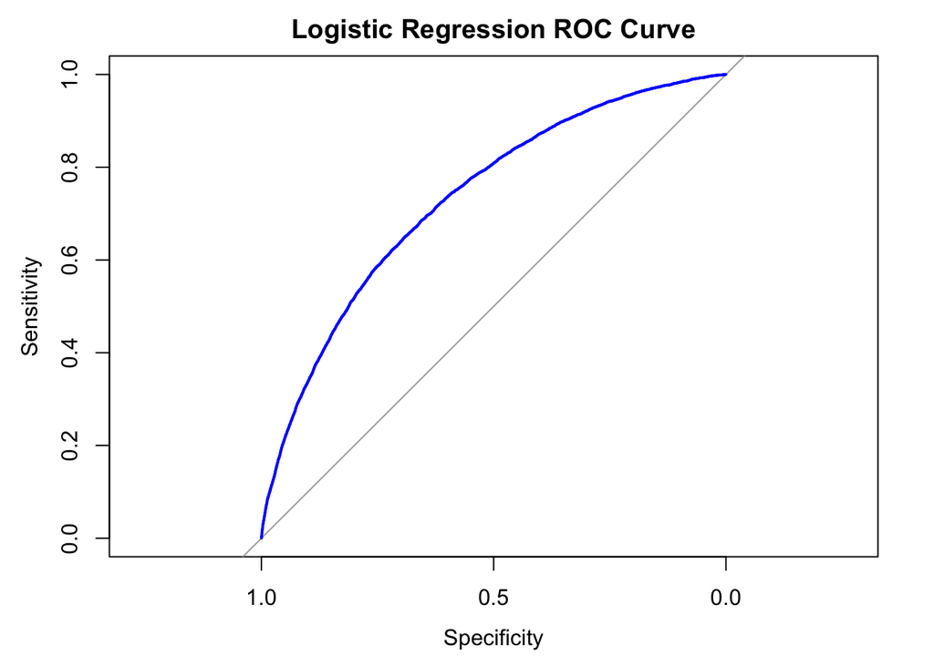

```r
#Predict downsampled with interactions on Test Data
logicPredunderInt <- predict(logicModelunderInt, appTest, type = 'response')

#Create ROC Curve
logicROCunderInt <- roc(appTest$TARGET, logicPredunderInt)

#Plot ROC Curve
plot(logicROCunderInt, col = 'blue', main = 'Logistic Regression ROC Curve')
```

```r
#Calculate AUC
auc(logicROCunderInt)
```

```
## Area under the curve: 0.7326
```

```r
#Threshold to predict
logicPredunderInt$predictor <- ifelse(logicPredunderInt > 0.5, "Yes", "No")
logicPredunderInt$predictor <- as.factor(logicPredunderInt$predictor)

#Confusion Matrix with percentages
confusionMatrix(logicPredunderInt$predictor, appTest$TARGET, positive = 'Yes')
```

```
## Confusion Matrix and Statistics
##
##           Reference
## Prediction    No   Yes
##        No  57153  2495
##        Yes 27651  4952
##
##                Accuracy : 0.6732
##                  95% CI : (0.6702, 0.6762)
##     No Information Rate : 0.9193
##     P-Value [Acc > NIR] : 1
##
##                   Kappa : 0.1334
##
##  Mcnemar's Test P-Value : <2e-16
##
##             Sensitivity : 0.66497
##             Specificity : 0.67394
##          Pos Pred Value : 0.15189
##          Neg Pred Value : 0.95817
##              Prevalence : 0.08073
##          Detection Rate : 0.05368
##    Detection Prevalence : 0.35342
##       Balanced Accuracy : 0.66945
##
##        'Positive' Class : Yes
##
```

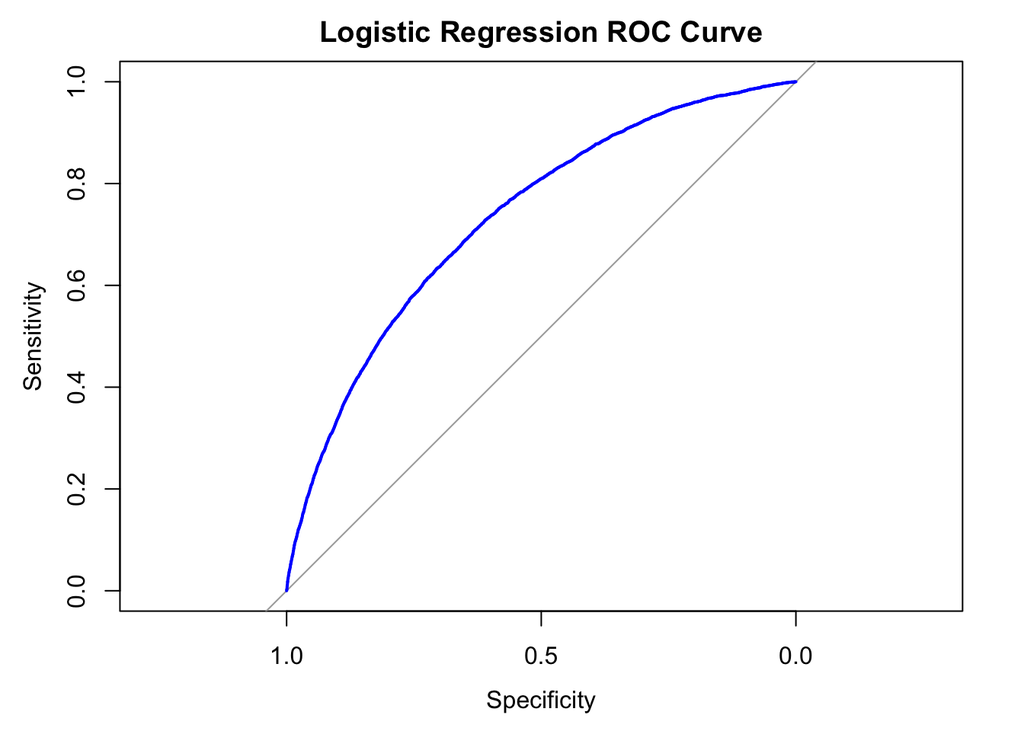

```r
#Predict downsampled without interactions on Test Data
logicPredunder <- predict(logicModelunder, appTest, type = 'response')

#Create ROC Curve
logicROCunder <- roc(appTest$TARGET, logicPredunder)

#Plot ROC Curve
plot(logicROCunder, col = 'blue', main = 'Logistic Regression ROC Curve')
```

```r
#Calculate AUC
auc(logicROCunder)
```

```
## Area under the curve: 0.732
```

```r
#Ensure numeric
logicPredunder <- as.numeric(logicPredunder)

#Threshold to predict
logicPredunder$predictor <- ifelse(logicPredunder > 0.5, "Yes", "No")
logicPredunder$predictor <- as.factor(logicPredunder$predictor)

#Confusion Matrix with percentages
confusionMatrix(logicPredunder$predictor, appTest$TARGET, positive = 'Yes')
```

```
## Confusion Matrix and Statistics
##
##           Reference
## Prediction    No   Yes
##        No  57856  2567
##        Yes 26948  4880
##
##                Accuracy : 0.6801
##                  95% CI : (0.677, 0.6831)
##     No Information Rate : 0.9193
##     P-Value [Acc > NIR] : 1
##
##                   Kappa : 0.1354
##
##  Mcnemar's Test P-Value : <2e-16
##
##             Sensitivity : 0.65530
##             Specificity : 0.68223
##          Pos Pred Value : 0.15332
##          Neg Pred Value : 0.95752
##              Prevalence : 0.08073
##          Detection Rate : 0.05290
##    Detection Prevalence : 0.34502
##       Balanced Accuracy : 0.66876
##
##        'Positive' Class : Yes
##
```

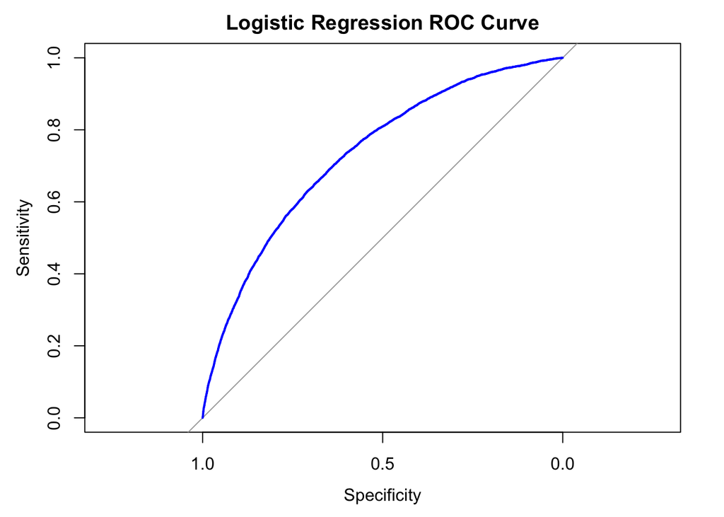

```r
#Original Logistic Model with no downsampling
logicPred <- predict(logitModel, appTest, type = 'response')


#Create ROC Curve
logicROC <- roc(appTest$TARGET, logicPred)

#Plot ROC Curve
plot(logicROC, col = 'blue', main = 'Logistic Regression ROC Curve')
```

```r
#Calculate AUC
auc(logicROC)
```

```
## Area under the curve: 0.7321
```

```r
#Ensure numeric
logicPred <- as.numeric(logicPred)

#Threshold to predict
logicPred$predictor <- ifelse(logicPred > 0.5, "Yes", "No")
logicPred$predictor <- as.factor(logicPred$predictor)

#Confusion Matrix with percentages
confusionMatrix(logicPred$predictor, appTest$TARGET, positive = 'Yes')
```

```
## Confusion Matrix and Statistics
##
##           Reference
## Prediction    No   Yes
##        No  84745  7411
##        Yes    59    36
##
##                Accuracy : 0.919
##                  95% CI : (0.9172, 0.9208)
##     No Information Rate : 0.9193
##     P-Value [Acc > NIR] : 0.6124
##
##                   Kappa : 0.0075
##
##  Mcnemar's Test P-Value : <2e-16
##
##             Sensitivity : 0.0048342
##             Specificity : 0.9993043
##          Pos Pred Value : 0.3789474
##          Neg Pred Value : 0.9195820
##              Prevalence : 0.0807254
##          Detection Rate : 0.0003902
##    Detection Prevalence : 0.0010298
##       Balanced Accuracy : 0.5020692
##
##        'Positive' Class : Yes
##
```

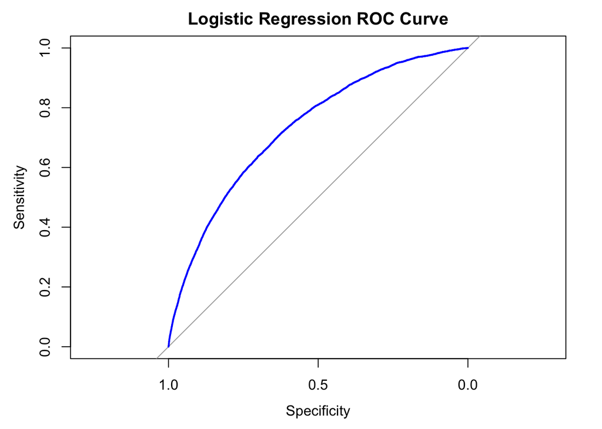

```r
#Upsample models
logicPredUp <- predict(logicModelover, appTest, type = 'response')

#Create ROC Curve
logicROCUp <- roc(appTest$TARGET, logicPredUp)

#Plot ROC Curve
plot(logicROCUp, col = 'blue', main = 'Logistic Regression ROC Curve')
```

```r
#Calculate AUC
auc(logicROCUp)
```

```
## Area under the curve: 0.732
```

```r
#Threshold to predict
logicPredUp$predictor <- ifelse(logicPredUp > 0.5, "Yes", "No")
logicPredUp$predictor <- as.factor(logicPredUp$predictor)

#Confusion Matrix with percentages
confusionMatrix(logicPredUp$predictor, appTest$TARGET, positive = 'Yes')
```

```
## Confusion Matrix and Statistics
##
##           Reference
## Prediction    No   Yes
##        No  57755  2565
##        Yes 27049  4882
##
##                Accuracy : 0.679
##                  95% CI : (0.676, 0.682)
##     No Information Rate : 0.9193
##     P-Value [Acc > NIR] : 1
##
##                   Kappa : 0.1347
##
##  Mcnemar's Test P-Value : <2e-16
##
##             Sensitivity : 0.65557
##             Specificity : 0.68104
##          Pos Pred Value : 0.15289
##          Neg Pred Value : 0.95748
##              Prevalence : 0.08073
##          Detection Rate : 0.05292
##    Detection Prevalence : 0.34613
##       Balanced Accuracy : 0.66830
##
##        'Positive' Class : Yes
##
```

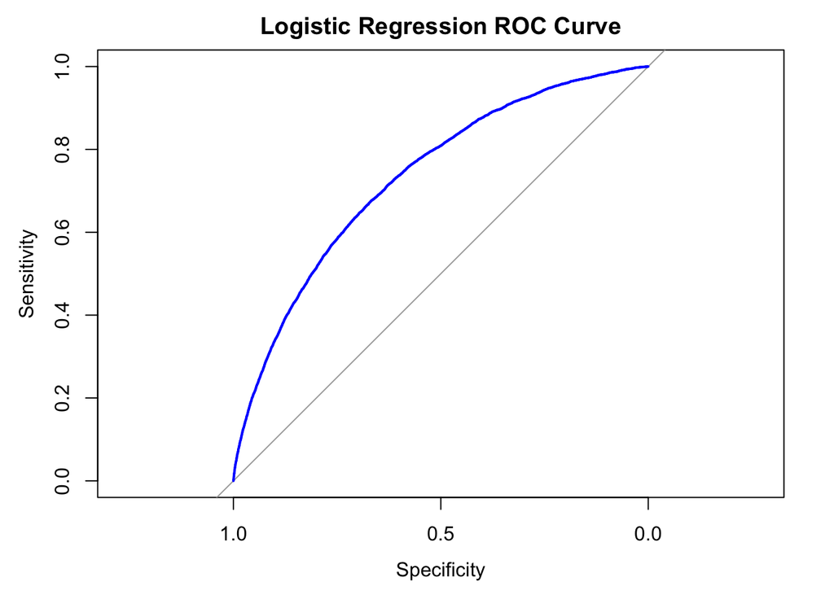

```r
#Upsample with interaction
logicPredUpInt <- predict(logicModeloverInt, appTest, type = 'response')

#Create ROC Curve
logicROCoverInt <- roc(appTest$TARGET, logicPredUpInt)

#Plot ROC Curve
plot(logicROCoverInt, col = 'blue', main = 'Logistic Regression ROC Curve')
```

```r
#Calculate AUC
auc(logicROCoverInt)
```

```
## Area under the curve: 0.7337
```

```r
#Threshold to predict
logicPredUpInt$predictor <- ifelse(logicPredUpInt > 0.5, "Yes", "No")
logicPredUpInt$predictor <- as.factor(logicPredUpInt$predictor)

#Confusion Matrix with percentages
confusionMatrix(logicPredUpInt$predictor, appTest$TARGET, positive = 'Yes')
```

```
## Confusion Matrix and Statistics
##
##           Reference
## Prediction    No   Yes
##        No  56846  2435
##        Yes 27958  5012
##
##                Accuracy : 0.6705
##                  95% CI : (0.6675, 0.6736)
##     No Information Rate : 0.9193
##     P-Value [Acc > NIR] : 1
##
##                   Kappa : 0.134
##
##  Mcnemar's Test P-Value : <2e-16
##
##             Sensitivity : 0.67302
##             Specificity : 0.67032
##          Pos Pred Value : 0.15202
##          Neg Pred Value : 0.95892
##              Prevalence : 0.08073
##          Detection Rate : 0.05433
##    Detection Prevalence : 0.35739
##       Balanced Accuracy : 0.67167
##
##        'Positive' Class : Yes
##
```

#Threshold to predict logicPred$predictor <- ifelse(logicPred > 0.1, "Yes", "No") logicPred$predictor <- as.factor(logicPred$predictor)

#Confusion Matrix with percentages confusionMatrix(logicPred$predictor, appTest$TARGET, positive = ‘Yes’)

#Confusion Matrix with percentages confusionMatrix(logicPredUp$predictor, appTest$TARGET, positive = ‘Yes’)

#Threshold to predict logicPred$predictor <- ifelse(logicPred > 0.2, "Yes", "No") logicPred$predictor <- as.factor(logicPred$predictor)

#Confusion Matrix with percentages confusionMatrix(logicPredUp$predictor, appTest$TARGET, positive = ‘Yes’)

#Confusion Matrix with percentages confusionMatrix(logicPred$predictor, appTest$TARGET, positive = ‘Yes’)

#Threshold to predict logicPred$predictor <- ifelse(logicPred > 0.3, "Yes", "No") logicPred$predictor <- as.factor(logicPred$predictor)

#Confusion Matrix with percentages confusionMatrix(logicPredUp$predictor, appTest$TARGET, positive = ‘Yes’)

#Confusion Matrix with percentages confusionMatrix(logicPred$predictor, appTest$TARGET, positive = ‘Yes’)

#Threshold to predict logicPred$predictor <- ifelse(logicPred > 0.4, "Yes", "No") logicPred$predictor <- as.factor(logicPred$predictor)

#Confusion Matrix with percentages confusionMatrix(logicPredUp$predictor, appTest$TARGET, positive = ‘Yes’)

#Confusion Matrix with percentages confusionMatrix(logicPred$predictor, appTest$TARGET, positive = ‘Yes’)

#Threshold to predict logicPred$predictor <- ifelse(logicPred > 0.5, "Yes", "No") logicPred$predictor <- as.factor(logicPred$predictor)

#Confusion Matrix with percentages confusionMatrix(logicPredUp$predictor, appTest$TARGET, positive = ‘Yes’)

#Confusion Matrix with percentages confusionMatrix(logicPred$predictor, appTest$TARGET, positive = ‘Yes’)

#Threshold to predict logicPred$predictor <- ifelse(logicPred > 0.6, "Yes", "No") logicPred$predictor <- as.factor(logicPred$predictor)

#Confusion Matrix with percentages confusionMatrix(logicPredUp$predictor, appTest$TARGET, positive = ‘Yes’)

#Confusion Matrix with percentages confusionMatrix(logicPred$predictor, appTest$TARGET, positive = ‘Yes’)

#Threshold to predict logicPred$predictor <- ifelse(logicPred > 0.7, "Yes", "No") logicPred$predictor <- as.factor(logicPred$predictor)

#Confusion Matrix with percentages confusionMatrix(logicPred$predictor, appTest$TARGET, positive = ‘Yes’)

#Threshold to predict logicPred$predictor <- ifelse(logicPred > 0.8, "Yes", "No") logicPred$predictor <- as.factor(logicPred$predictor)

#Confusion Matrix with percentages confusionMatrix(logicPred$predictor, appTest$TARGET, positive = ‘Yes’)

#Threshold to predict logicPred$predictor <- ifelse(logicPred > 0.9, "Yes", "No") logicPred$predictor <- as.factor(logicPred$predictor)

#Confusion Matrix with percentages confusionMatrix(logicPred$predictor, appTest$TARGET, positive = ‘Yes’)